# R vs Tableau (LOD) (dataset Superstore)

Hurgland-Nick KELIET

Dans ce tutoriel, nous allons voir comment travailler avec R studio et son Notebook Rmarkdown, plus spécifiquement pour effectuer des analyses du monde réél, avec le dataset que vous trouverez dans le site de Tableau nommé “Global Superstore Orders” ou encore dans le lien suivant https://data.world/tableauhelp/superstore-data-sets. Vous aurez dans certains cas à traiter le dataset pour avoir de bons résultats car le dataset a des données à emputer surtout si vous voulez faire du Machine Learning avec.

Bref, Ici Nous allons utiliser un haut niveau de Tableau appelé Level of Detail(LOD) ce qui nous permettra de pousser de manière fine nos analyses et effectuer des visualisations très complexes grâce à des aggregations. Rappelons que Tableau nous aide facilement à créer des graphes grâce à des Drag_&*Drop, mais dans le monde réel, parfois les Drag*&_Drop ne suffisent pas. C’est la raison pour laquelle nous allons comparer la visualisation entre R et Tableau avec quelque fois l’équivalent SQL, afin que si vous avez déjà un usage de R que vous puissiez comprendre comment fonctionne Tableau et vice-versa en performant facilement le “LOD” que je trouve super passionnant par sa complexité et surtout par sa précision.(Tout est une question de compréhension certains le trouverons très facile après 😉!!!!).

Je vous conseil d’avoir Tableau et R dans votre pc pour pouvoir en même temps effectuer des testes, c’est super formateur et on se fait très vite une idée sur nos préférences selon les problématiques, ce qui vous aidera très fortement dans vos analyses et présentations en entreprise.

**Voici le lien avec les graphes R en dynamique (Veuillez l'utiliser en parallèle à cette page svp!!): [Lien Rpubs](https://rpubs.com/Hurgland-Nick/645742)**

### Import des librairies

```r
# Manipulation des dataframes
library(tidyverse)
# Traiter les dates
library(lubridate)
```

```r
# ggplot
library(ggplot2)

# Visualisation interactive
library(plotly)
library(ggplotlyExtra)
# Manipulation des tables
library(data.table)
# Manipulation des tables avec SQLDF
library(sqldf)
```

### Importation des données

```r
superstore <- fread("sup_store.csv")

# Visualisation des 6 premières lignes
head(superstore)
```

```
##    Row_ID       Order_ID Order_Date  Ship_Date      Ship_Mode Customer_ID
## 1:  32298 CA-2012-124891 31/07/2012 31/07/2012       Same Day    RH-19495
## 2:  40155 CA-2014-135909 14/10/2014 21/10/2014 Standard Class    JW-15220
## 3:  40936 CA-2012-116638 28/01/2012 31/01/2012   Second Class    JH-15985
## 4:  34577 CA-2011-102988 05/04/2011 09/04/2011   Second Class    GM-14695
## 5:  36178 CA-2014-143567 03/11/2014 06/11/2014   Second Class    TB-21175
## 6:  31784 CA-2011-154627 29/10/2011 31/10/2011    First Class    SA-20830
##    Customer_Name   Segment          City          State       Country
## 1:   Rick Hansen  Consumer New York City       New York United States
## 2:     Jane Waco Corporate    Sacramento     California United States
## 3:   Joseph Holt  Consumer       Concord North Carolina United States
## 4:  Greg Maxwell Corporate    Alexandria       Virginia United States
## 5: Thomas Boland Corporate     Henderson       Kentucky United States
## 6:  Sue Ann Reed  Consumer       Chicago       Illinois United States
##    Postal_Code Market  Region      Product_ID        Category Sub-Category
```

[output cut: 20 more lines]

### Vérification de la structure de notre dataset

```r
str(superstore)
```

```
## Classes 'data.table' and 'data.frame':   9994 obs. of  24 variables:
##  $ Row_ID        : int  32298 40155 40936 34577 36178 31784 37311 32735 32543 36423 ...
##  $ Order_ID      : chr  "CA-2012-124891" "CA-2014-135909" "CA-2012-116638" "CA-2011-102988" ...
##  $ Order_Date    : chr  "31/07/2012" "14/10/2014" "28/01/2012" "05/04/2011" ...
##  $ Ship_Date     : chr  "31/07/2012" "21/10/2014" "31/01/2012" "09/04/2011" ...
##  $ Ship_Mode     : chr  "Same Day" "Standard Class" "Second Class" "Second Class" ...
##  $ Customer_ID   : chr  "RH-19495" "JW-15220" "JH-15985" "GM-14695" ...
##  $ Customer_Name : chr  "Rick Hansen" "Jane Waco" "Joseph Holt" "Greg Maxwell" ...
##  $ Segment       : chr  "Consumer" "Corporate" "Consumer" "Corporate" ...
##  $ City          : chr  "New York City" "Sacramento" "Concord" "Alexandria" ...
##  $ State         : chr  "New York" "California" "North Carolina" "Virginia" ...
##  $ Country       : chr  "United States" "United States" "United States" "United States" ...
##  $ Postal_Code   : int  10024 95823 28027 22304 42420 60610 90008 79109 93727 10009 ...
##  $ Market        : chr  "US" "US" "US" "US" ...
##  $ Region        : chr  "East" "West" "South" "South" ...
##  $ Product_ID    : chr  "TEC-AC-10003033" "OFF-BI-10003527" "FUR-TA-10000198" "OFF-SU-10002881" ...
##  $ Category      : chr  "Technology" "Office Supplies" "Furniture" "Office Supplies" ...
##  $ Sub-Category  : chr  "Accessories" "Binders" "Tables" "Supplies" ...
##  $ Product_Name  : chr  "Plantronics CS510 - Over-the-Head monaural Wireless Headset System" "Fellowes PB500 Electric Punch Plastic Comb Binding Machine with Manual Bind" "Chromcraft Bull-Nose Wood Oval Conference Tables & Bases" "Martin Yale Chadless Opener Electric Letter Opener" ...
##  $ Sales         : num  2310 5084 4298 4164 2250 ...
##  $ Quantity      : int  7 5 13 5 9 6 8 5 12 4 ...
##  $ Discount      : chr  "0" "0,2" "0,4" "0" ...
##  $ Profit        : num  762.2 1906.5 -1862.3 83.3 517.5 ...
##  $ Shipping_Cost : num  934 868 866 847 781 ...
##  $ Order_Priority: chr  "Critical" "Low" "Critical" "High" ...
##  - attr(*, ".internal.selfref")=<externalptr>
```

### Utilisation de lubridate pour change le format des date “Order Date” et “Ship Date”

```r
# Convertion de la date de commande
superstore$`Order_Date` <- dmy(superstore$`Order_Date`)

# Convertion de la date d'envoie
superstore$`Ship_Date` <- dmy(superstore$`Ship_Date`)

# Visualisation de la structure de notre dataframe
str(superstore)
```

```
## Classes 'data.table' and 'data.frame':   9994 obs. of  24 variables:
##  $ Row_ID        : int  32298 40155 40936 34577 36178 31784 37311 32735 32543 36423 ...
##  $ Order_ID      : chr  "CA-2012-124891" "CA-2014-135909" "CA-2012-116638" "CA-2011-102988" ...
##  $ Order_Date    : Date, format: "2012-07-31" "2014-10-14" ...
##  $ Ship_Date     : Date, format: "2012-07-31" "2014-10-21" ...
##  $ Ship_Mode     : chr  "Same Day" "Standard Class" "Second Class" "Second Class" ...
##  $ Customer_ID   : chr  "RH-19495" "JW-15220" "JH-15985" "GM-14695" ...
##  $ Customer_Name : chr  "Rick Hansen" "Jane Waco" "Joseph Holt" "Greg Maxwell" ...
##  $ Segment       : chr  "Consumer" "Corporate" "Consumer" "Corporate" ...
##  $ City          : chr  "New York City" "Sacramento" "Concord" "Alexandria" ...
##  $ State         : chr  "New York" "California" "North Carolina" "Virginia" ...
##  $ Country       : chr  "United States" "United States" "United States" "United States" ...
##  $ Postal_Code   : int  10024 95823 28027 22304 42420 60610 90008 79109 93727 10009 ...
##  $ Market        : chr  "US" "US" "US" "US" ...
##  $ Region        : chr  "East" "West" "South" "South" ...
##  $ Product_ID    : chr  "TEC-AC-10003033" "OFF-BI-10003527" "FUR-TA-10000198" "OFF-SU-10002881" ...
##  $ Category      : chr  "Technology" "Office Supplies" "Furniture" "Office Supplies" ...
##  $ Sub-Category  : chr  "Accessories" "Binders" "Tables" "Supplies" ...
##  $ Product_Name  : chr  "Plantronics CS510 - Over-the-Head monaural Wireless Headset System" "Fellowes PB500 Electric Punch Plastic Comb Binding Machine with Manual Bind" "Chromcraft Bull-Nose Wood Oval Conference Tables & Bases" "Martin Yale Chadless Opener Electric Letter Opener" ...
##  $ Sales         : num  2310 5084 4298 4164 2250 ...
##  $ Quantity      : int  7 5 13 5 9 6 8 5 12 4 ...
##  $ Discount      : chr  "0" "0,2" "0,4" "0" ...
##  $ Profit        : num  762.2 1906.5 -1862.3 83.3 517.5 ...
##  $ Shipping_Cost : num  934 868 866 847 781 ...
##  $ Order_Priority: chr  "Critical" "Low" "Critical" "High" ...
##  - attr(*, ".internal.selfref")=<externalptr>
```

### Mettre des colonnes dans le bon type

```r
superstore$Profit = as.numeric(superstore$Profit)
superstore$Sales = as.numeric(superstore$Sales)
str(superstore)
```

```
## Classes 'data.table' and 'data.frame':   9994 obs. of  24 variables:
##  $ Row_ID        : int  32298 40155 40936 34577 36178 31784 37311 32735 32543 36423 ...
##  $ Order_ID      : chr  "CA-2012-124891" "CA-2014-135909" "CA-2012-116638" "CA-2011-102988" ...
##  $ Order_Date    : Date, format: "2012-07-31" "2014-10-14" ...
##  $ Ship_Date     : Date, format: "2012-07-31" "2014-10-21" ...
##  $ Ship_Mode     : chr  "Same Day" "Standard Class" "Second Class" "Second Class" ...
##  $ Customer_ID   : chr  "RH-19495" "JW-15220" "JH-15985" "GM-14695" ...
##  $ Customer_Name : chr  "Rick Hansen" "Jane Waco" "Joseph Holt" "Greg Maxwell" ...
##  $ Segment       : chr  "Consumer" "Corporate" "Consumer" "Corporate" ...
##  $ City          : chr  "New York City" "Sacramento" "Concord" "Alexandria" ...
##  $ State         : chr  "New York" "California" "North Carolina" "Virginia" ...
##  $ Country       : chr  "United States" "United States" "United States" "United States" ...
##  $ Postal_Code   : int  10024 95823 28027 22304 42420 60610 90008 79109 93727 10009 ...
##  $ Market        : chr  "US" "US" "US" "US" ...
##  $ Region        : chr  "East" "West" "South" "South" ...
##  $ Product_ID    : chr  "TEC-AC-10003033" "OFF-BI-10003527" "FUR-TA-10000198" "OFF-SU-10002881" ...
##  $ Category      : chr  "Technology" "Office Supplies" "Furniture" "Office Supplies" ...
##  $ Sub-Category  : chr  "Accessories" "Binders" "Tables" "Supplies" ...
##  $ Product_Name  : chr  "Plantronics CS510 - Over-the-Head monaural Wireless Headset System" "Fellowes PB500 Electric Punch Plastic Comb Binding Machine with Manual Bind" "Chromcraft Bull-Nose Wood Oval Conference Tables & Bases" "Martin Yale Chadless Opener Electric Letter Opener" ...
##  $ Sales         : num  2310 5084 4298 4164 2250 ...
##  $ Quantity      : int  7 5 13 5 9 6 8 5 12 4 ...
##  $ Discount      : chr  "0" "0,2" "0,4" "0" ...
##  $ Profit        : num  762.2 1906.5 -1862.3 83.3 517.5 ...
##  $ Shipping_Cost : num  934 868 866 847 781 ...
##  $ Order_Priority: chr  "Critical" "Low" "Critical" "High" ...
##  - attr(*, ".internal.selfref")=<externalptr>
```

# Requêtes

## 1) Profit Mensuel Pour Chaque Année

```r
requete_1 <- superstore %>% group_by(Order_Date) %>%
                            summarise(Profit_journalier = round(sum(Profit),1)) %>%
                            mutate(Year = lubridate::year(Order_Date), Month = lubridate::month(Order_Date,label=TRUE,abbr=TRUE))
requete_1 <- requete_1 %>% group_by(Year, Month) %>%
                           summarise(total_ventes_mensuel = sum(Profit_journalier)) %>%
                           group_by(total_ventes_mensuel ,Year, Month)
```

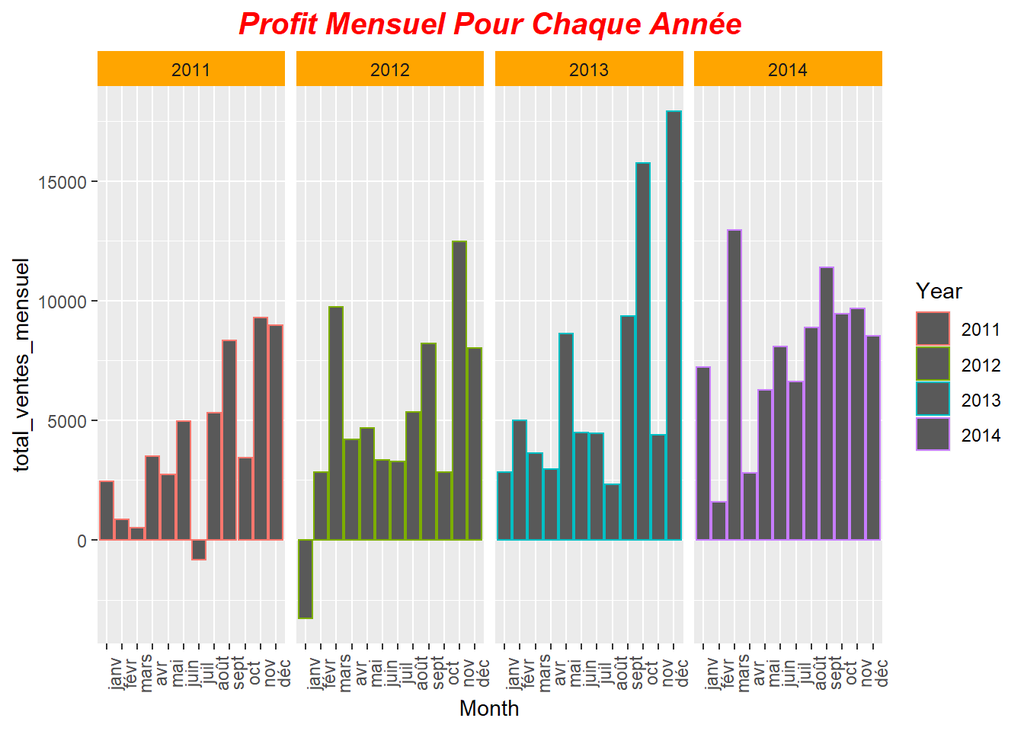

```r
# Graphe
requete_1_graphe <- requete_1 %>% ggplot(aes(Month, y = total_ventes_mensuel)) + geom_bar(stat = 'identity', aes(color = factor(Year))) +
                                  facet_wrap(~ Year, ncol = 4) +
                                  ggtitle("Profit Mensuel Pour Chaque Année")+
                                  scale_colour_discrete(name = "Year") +
                                  theme(axis.text.x = element_text(angle = 90), strip.background = element_rect(fill="orange"), plot.title = element_text(size = 15, hjust = 0.5, color = "red", face ="bold.italic"))
requete_1_graphe
```

**Solution de cette requête sur tableau software**

[figure not shown]

Screen du process de l'implémentation de la solution sur tableau

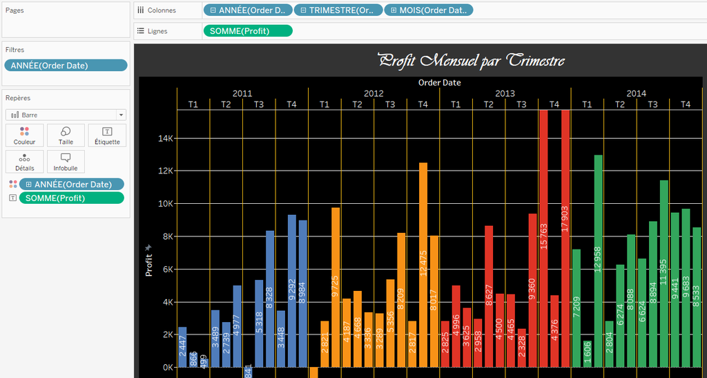

## Requête 2: Nombre de Jour Rentable dans le Mois

supposons: si le profit est supérieur à 200 dollars, alors la journée est très rentable si le profit est inférieur à 0 dollars, alors la journée n’est pas rentable sinon est rentable entre 0 et 200 dollars

```r
requete_2 <- superstore %>% group_by(Order_Date) %>%
                            summarise(Profit_journalier = sum(Profit)) %>%
                            mutate(Rentabilite = ifelse(Profit_journalier  > 200, "Très Rentable",
                            ifelse(Profit_journalier < 0, "Non Rentable" , "Rentable")))
requete_2 <- requete_2 %>% mutate(Year = lubridate::year(Order_Date), Month = lubridate::month(Order_Date,label=TRUE,abbr=TRUE)) %>% group_by(Rentabilite, Year, Month) %>% summarise(Count = n())
```

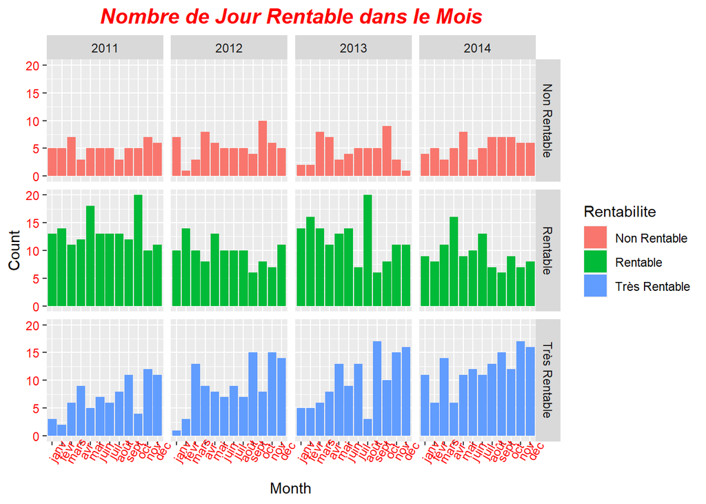

```r
# Graphe
requete_2_graphe <- requete_2 %>% ggplot(aes(Month, Count)) +
                    facet_grid(Rentabilite ~ Year) +
                    geom_bar(stat = "identity", aes(fill = Rentabilite)) +
                    ggtitle("Nombre de Jour Rentable dans le Mois") +
                    theme(axis.text.x = element_text(angle = 60, color = "red"), axis.text.y = element_text(color = "red"), plot.title = element_text(size = 15, hjust = 0.5, color = "red", face ="bold.italic"))

requete_2_graphe
```

**Solution de cette requête sur tableau software**

[figure not shown]

Screen du process de l'implémentation de la solution sur tableau

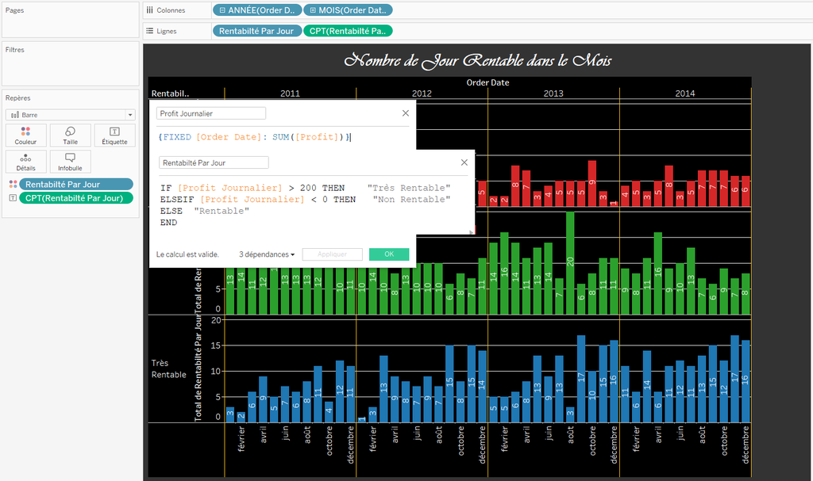

## Requête 3: Le pourcentage de client ayant effectué des commandes en 2013 et en 2014

*R*

```r
# Clients ayant commandé en 2014
client_en_2014 <- superstore %>%
                    filter(lubridate::year(Order_Date) == 2014)

# Clients 2013 ayant commandé en 2014
client_en_2013_dans_2014 <- superstore %>%
                           filter(lubridate::year(Order_Date) == 2013) %>%
                           filter(`Customer_ID` %in% unique(client_en_2014$`Customer_ID`))

# Clients ayant commandé en 2013 et pas en 2014
client_2013_et_pas_en_2014 <- superstore %>% filter(lubridate::year(`Order_Date`) == 2013) %>%
                              filter(!(`Customer_ID` %in% unique(client_en_2014$`Customer_ID`)))

# calcul du pourcentage
requete_3 <- length(unique(client_en_2013_dans_2014$`Customer_ID`)) / (length(unique(client_en_2013_dans_2014$`Customer_ID`)) +     length(unique(client_2013_et_pas_en_2014$`Customer_ID`))) * 100

# Print
#message(paste0(round(requete_3, 2), "% des clients ont commandé en 2013 et également en 2014"))
message(paste0("Le pourcentage de client ayant commandé en 2013 et également en 2014 est de "), round(requete_3, 2), "%")
```

```
## Le pourcentage de client ayant commandé en 2013 et également en 2014 est de 87.44%
```

**Solution de cette requête sur tableau software**

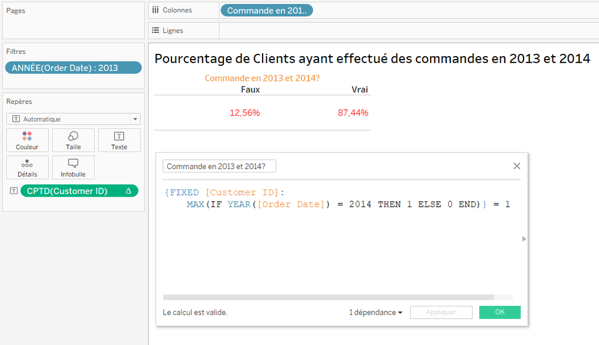

## Requête 4: Le Nombre de client qui ont effectué plus de 10 commandes

*SQL*

```r
req_3_sql <- sqldf("select count(distinct(Order_ID)) as nb_diff_order from superstore group by Customer_ID having nb_diff_order > 10") %>% nrow()
req_3_sql
```

```
## [1] 49
```

*Résultat:* **On obtient bien 49 lignes.**

*R*

```r
req_4_R <- superstore %>% distinct(Order_ID,Customer_Name) %>%
                          group_by(Customer_Name) %>%
                          summarise(nb_diff_order = n()) %>%
                          filter(nb_diff_order > 10)
client_ayant_plusde_10_commandes <- nrow(req_4_R)
client_ayant_plusde_10_commandes
```

```
## [1] 49
```

*Résultat:* **On obtient également 49 lignes.**

**Solution de cette requête sur tableau software**

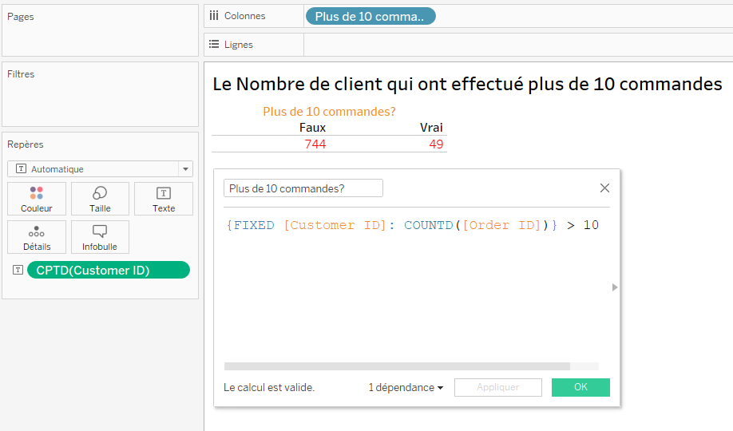

### Requête 4.2: La valeur moyenne des ventes pour les commandes qui incluent la technologie comme Catégorie.

Sachant que une seule commande peut inclure plusieurs Catégories de produits. Chaque article est sur et sera sur une ligne de donnée différentes mais partage un même ID de commande.

```r
# Récupérons notre Catégorie "Technology"
technologie = superstore %>% filter(Category =="Technology")

# Récupérons l'ID unique
Liste_des_IDS_technology = unique(technologie$Order_ID)

# récupération eds commandes qui possèdent comme catégorie Technologie
commandes_contenant_technologie =  superstore %>% filter(Order_ID %in% Liste_des_IDS_technology)

# Requête
requete_42_R = sum(commandes_contenant_technologie$Sales)/(length(Liste_des_IDS_technology))

message(paste0("La valeur moyenne des ventes pour les commandes qui incluent la technologie comme Catégorie est : ", round(requete_42_R, 2)))
```

```
## La valeur moyenne des ventes pour les commandes qui incluent la technologie comme Catégorie est : 822
```

**Solution de cette requête sur tableau software**

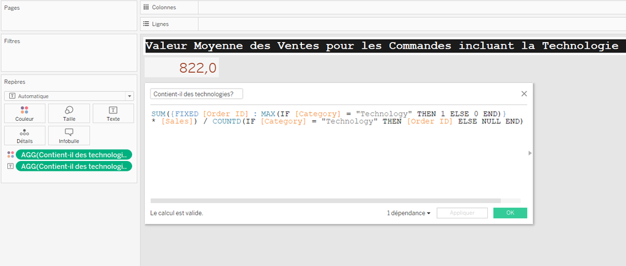

## Requête 5: Le nombre de jour en Mars 2013 ayant des Profits positifs et négatifs

*R*

```r
requete_5 <- superstore %>% filter(lubridate::year(Order_Date) == 2013, lubridate::month(Order_Date) == 3) %>%
                            group_by(Order_Date) %>%
                            summarise(somme_profit = sum(Profit)) %>%
                            mutate(Profit_positif = ifelse(somme_profit > 0, 'Oui','Non')) %>%
                            group_by(Profit_positif) %>% summarise(count = n())
requete_5
```

```
## # A tibble: 2 x 2
##   Profit_positif count
##   <chr>          <int>
## 1 Non                8
## 2 Oui               20
```

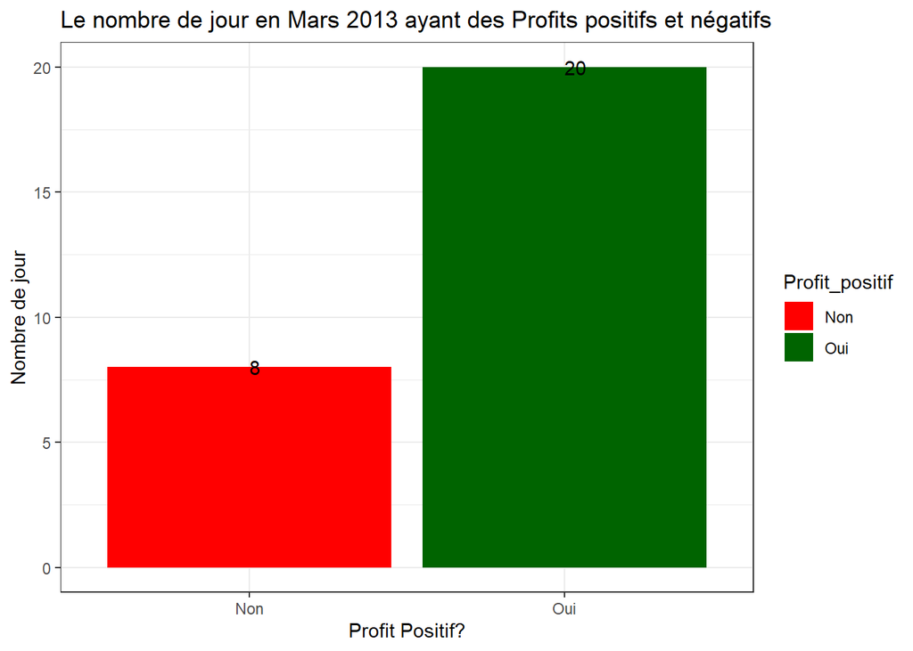

```r
# Graphe
requete_5_graphe <- requete_5 %>% ggplot(aes(Profit_positif, count, fill = Profit_positif)) +
                                  geom_bar(stat = "identity") +
                                  geom_text(aes(label = count, hjust = 0, vjust = 0.5)) +
                                  ggtitle("Le nombre de jour en Mars 2013 ayant des Profits positifs et négatifs") +
                                  xlab("Profit Positif?") +
                                  ylab("Nombre de jour") +
                                  scale_fill_manual(values = c("Non" = "red", "Oui" = "darkgreen")) +
                                  theme(plot.title = element_text(size = 15, hjust = 0.5, color = "red")) +
                                  theme_bw()
requete_5_graphe
```

**Solution de cette requête sur tableau software**

[figure not shown]

Screen du process de l'implémentation de la solution sur tableau

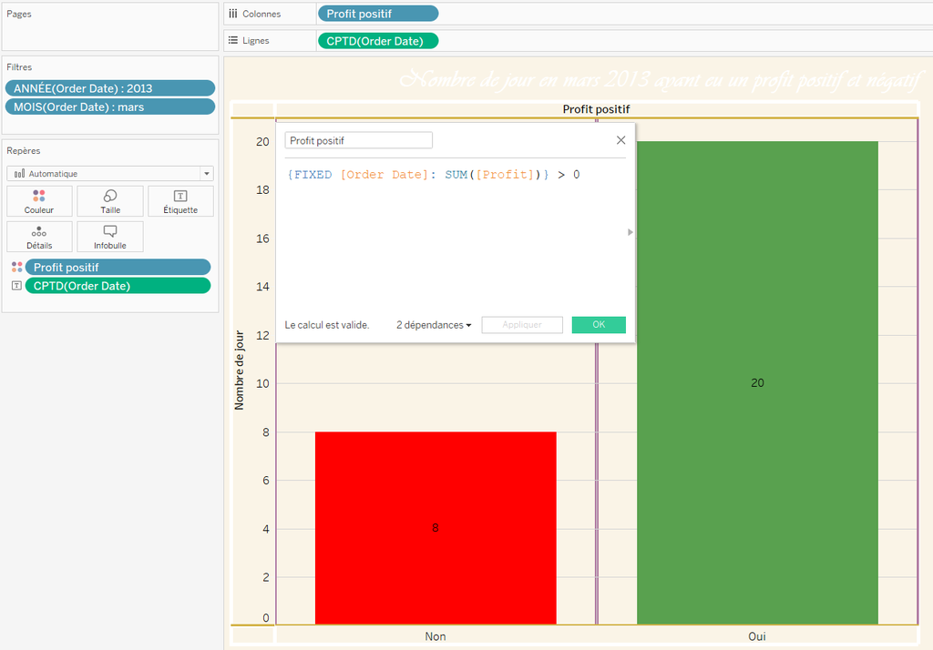

## Requête 6: Combien de Client ont fait 1, 2, 3, N Commandes?

*SQL*

```r
req_6_sql <- sqldf("select count(distinct(Order_ID)) as nombre_de_commande from superstore group by Customer_ID")
req_6_sql <- sqldf("select count(*), nombre_de_commande from req_6_sql group by nombre_de_commande")
req_6_sql
```

```
##    count(*) nombre_de_commande
## 1        12                  1
## 2        34                  2
## 3        53                  3
## 4        96                  4
## 5       134                  5
## 6       107                  6
## 7       116                  7
## 8        82                  8
## 9        71                  9
## 10       39                 10
## 11       23                 11
## 12       18                 12
## 13        7                 13
## 14        1                 17
```

*R*

```r
requete_6_R <- superstore %>% distinct(Customer_ID,Order_ID) %>%
                            group_by(Customer_ID) %>%
                            summarise(nombre_de_commande = n()) %>%
                            group_by(nombre_de_commande) %>%
                            summarise(nombre_de_client= n())
requete_6_R
```

```
## # A tibble: 14 x 2
##    nombre_de_commande nombre_de_client
##                 <int>            <int>
##  1                  1               12
##  2                  2               34
##  3                  3               53
##  4                  4               96
##  5                  5              134
##  6                  6              107
##  7                  7              116
##  8                  8               82
##  9                  9               71
## 10                 10               39
## 11                 11               23
## 12                 12               18
## 13                 13                7
## 14                 17                1
```

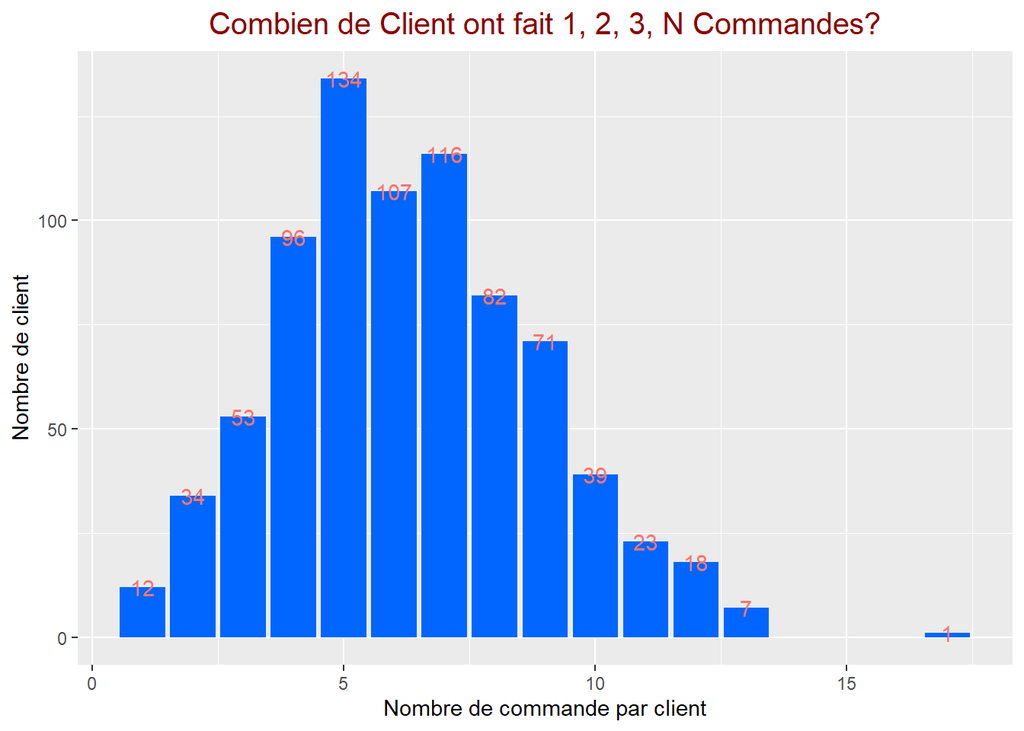

```r
# Graphe
requete_6_graphe <- requete_6_R %>% ggplot(aes(nombre_de_commande, nombre_de_client)) +
                                    geom_bar(stat = "identity", fill = "#0066FF") +
                                    geom_text(aes(label = nombre_de_client, hjust = 0.5, color = "white")) +
                                    ggtitle("Combien de Client ont fait 1, 2, 3, N Commandes?") +
                                    xlab("Nombre de commande par client") +
                                    ylab("Nombre de client") +
                                    theme(legend.position = "none") +
                                    theme(plot.title = element_text(size = 15, hjust = 0.5, color = "darkred"))
requete_6_graphe
```

**Solution de cette requête sur tableau software**

[figure not shown]

Screen du process de l'implémentation de la solution sur tableau

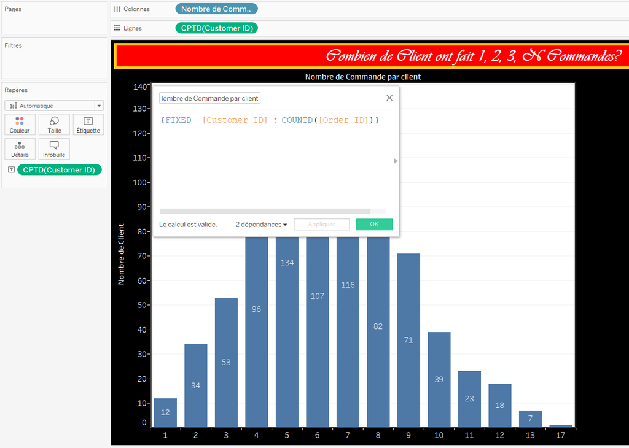

## Requête 7: Pourcentage des ventes par Etat (5 principaux Etats)

*SQL*

```r
req_7_sql <- sqldf("select round((sum(Sales) * 100)/ (select sum(Sales) from superstore),2) as somme_sales,State from superstore group by State order by somme_sales desc limit 5")

req_7_sql
```

```
##   somme_sales        State
## 1       19.92   California
## 2       13.53     New York
## 3        7.41        Texas
## 4        6.04   Washington
## 5        5.07 Pennsylvania
```

*R*

```r
# Total des ventes dans le dataset
Total_des_ventes <- sum(superstore$Sales)
message(paste0("Le total des ventes dans le dataset est de: "),Total_des_ventes, " dollars")
```

```
## Le total des ventes dans le dataset est de: 2297200.8603 dollars
```

```r
# Pourcentage des ventes par Etat (top 5)
req_7_R <- superstore %>% select(State, Sales) %>%
                          group_by(State) %>%
                          summarise(pourcentage_sales = round(sum(Sales) * 100 / Total_des_ventes,2)) %>%
                          arrange(desc(pourcentage_sales)) %>%
                          head(5)
req_7_R
```

```
## # A tibble: 5 x 2
##   State        pourcentage_sales
##   <chr>                    <dbl>
## 1 California               19.9
## 2 New York                 13.5
## 3 Texas                     7.41
## 4 Washington                6.04
## 5 Pennsylvania              5.07
```

**Solution de cette requête sur tableau software**

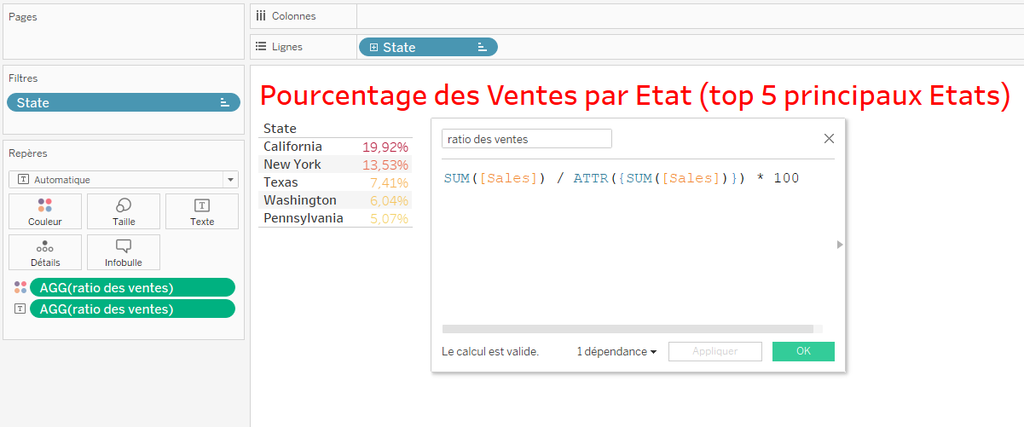

## Requête 8: Revenue Annuel de chaque Cohorte de Client

```r
req_8_R <- superstore %>% inner_join(superstore %>%
                                    group_by(Customer_ID) %>%
                                    summarise(annee_subscription = lubridate::year(min(Order_Date))), by = "Customer_ID") %>%
                                    mutate(annee_subscription = as.factor(annee_subscription)) %>%
                                    group_by(annee_commande = lubridate::year(Order_Date), annee_subscription) %>%
                                    summarise(Total_Sales  = round(sum(Sales), 0))
```

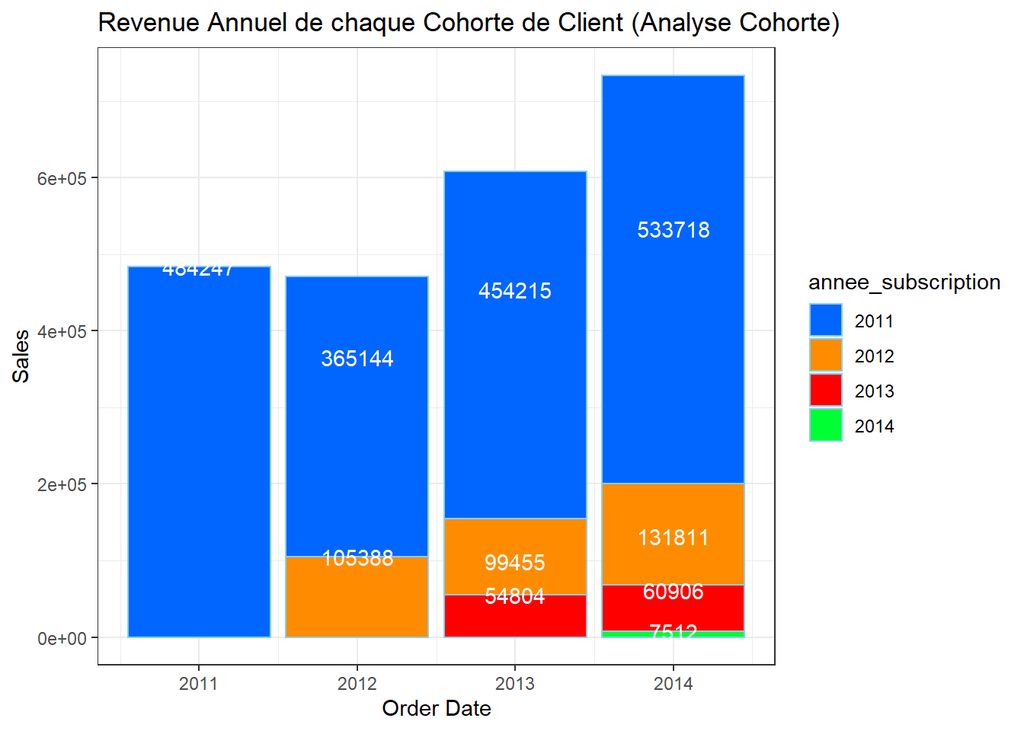

```r
# Graphe
req_8_R <- req_8_R %>% ggplot(aes(x = annee_commande, y = Total_Sales, fill = annee_subscription )) +
                       geom_bar(stat = "identity",color = 'skyblue') +
                       geom_text(aes(label = Total_Sales), color = "white", hjust = 0.5) +
                       scale_fill_manual(values = c("2011" = "#0066FF", "2012" = "darkorange","2013" = "red", "2014" = "#00FF33")) +
                       xlab("Order Date") + ylab("Sales") + ggtitle("Revenue Annuel de chaque Cohorte de Client (Analyse Cohorte)") +
                       theme(plot.title = element_text(size = 15, hjust = 0.5, color = "red")) +
                       theme_bw()

# Afficher le Graphe
req_8_R
```

**Solution de cette requête sur tableau software**

[figure not shown]

Screen du process de l'implémentation de la solution sur tableau

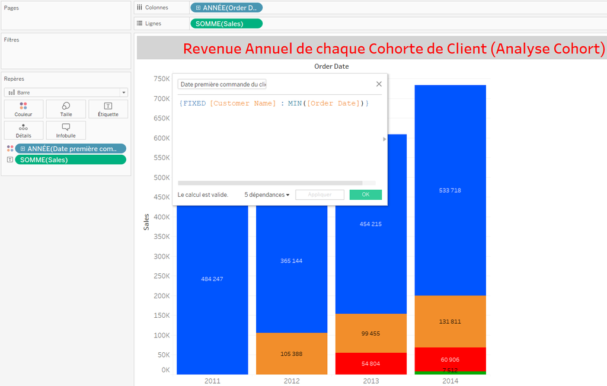

## Requête 9: Tendance - Nombre de Clients Acquis par Jour et par État pour les cinq principaux États en termes de Ventes

```r
# Les le Top 5 des vendeurs par Etat
top_5_Etat_par_vente <- superstore %>% group_by(State) %>%
                                       summarise(somme_vente = sum(Sales)) %>%
                                       arrange(desc(somme_vente)) %>%
                                       head(5) %>% .$State
# Requête
req_9_R = superstore %>% inner_join(superstore %>% group_by(Customer_ID) %>%
                                                    summarise(premiere_date_commande = min(Order_Date)), by = "Customer_ID") %>%
                                                    mutate(Existant = ifelse(Order_Date == premiere_date_commande, "Oui", "NON")) %>%
                                                    filter(Existant == "Oui") %>%
                                                    filter(State %in% top_5_Etat_par_vente) %>%
                                                    distinct(Customer_ID, .keep_all = TRUE) %>%
                                                    group_by(State,Order_Date) %>%
                                                    summarise(nouveau_clients = n())
# Créons un nouveau DataFrame
new_dataframe = data_frame()
```

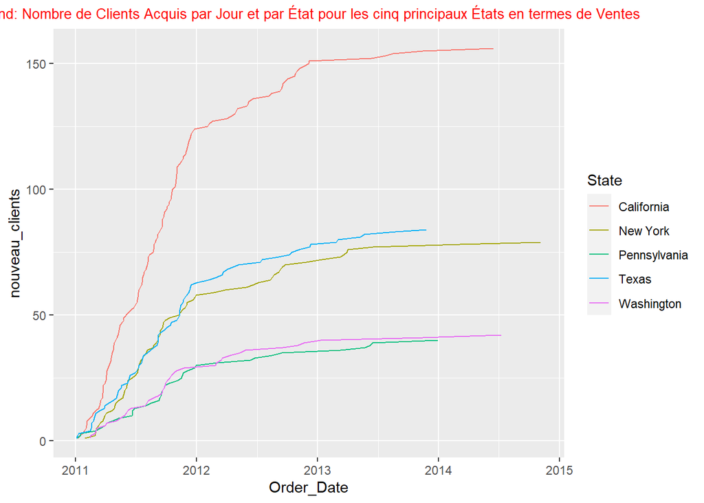

```r
for(etat in top_5_Etat_par_vente ){
    variable = req_9_R %>% filter(State == etat)
    variable$nouveau_clients = cumsum(variable$nouveau_clients)
    new_dataframe = bind_rows(new_dataframe, variable)
}

# Affichons le graphe
graphe <- new_dataframe  %>% ggplot(aes(Order_Date, nouveau_clients, color = State)) + geom_line() +
                             ggtitle("Trend: Nombre de Clients Acquis par Jour et par État pour les cinq principaux États en termes de Ventes") +
                             theme(plot.title = element_text(size = 10, hjust = 0.5, color = "red"))

graphe
```

**Solution de cette requête sur tableau software**

[figure not shown]

Screen du process de l'implémentation de la solution sur tableau

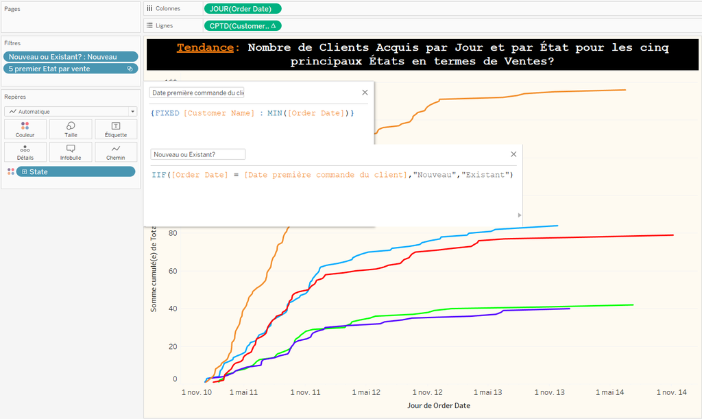